# Grando-8

#### Exercise 5 - Let’s see if the apparent trend in the plot is something more than natural variation. Fit a linear model called m_bty to predict average professor score by average beauty rating and add the line to your plot using abline(m_bty). Write out the equation for the linear model and interpret the slope. Is average beauty score a statistically significant predictor? Does it appear to be a practically significant predictor?

Answer:

```r
m_bty <- lm(score ~ bty_avg, data = evals)
summary(m_bty)
```

```
##
## Call:
## lm(formula = score ~ bty_avg, data = evals)
##
## Residuals:
##     Min      1Q  Median      3Q     Max
## -1.9246 -0.3690  0.1420  0.3977  0.9309
##
## Coefficients:
##             Estimate Std. Error t value Pr(>|t|)
## (Intercept)  3.88034    0.07614   50.96  < 2e-16 ***
## bty_avg      0.06664    0.01629    4.09 5.08e-05 ***
## ---
## Signif. codes:  0 '***' 0.001 '**' 0.01 '*' 0.05 '.' 0.1 ' ' 1
##
## Residual standard error: 0.5348 on 461 degrees of freedom
## Multiple R-squared:  0.03502,    Adjusted R-squared:  0.03293
## F-statistic: 16.73 on 1 and 461 DF,  p-value: 5.083e-05
```

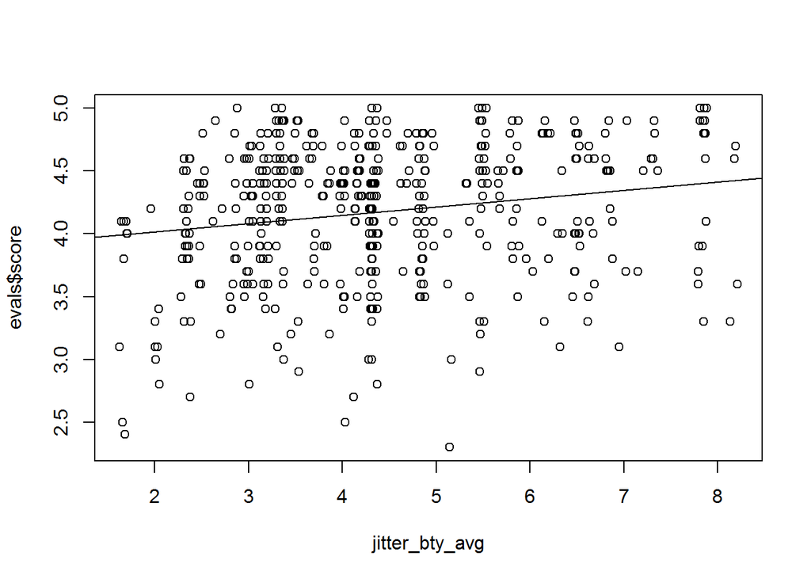

```r
plot(evals$score ~ jitter_bty_avg)
abline(m_bty)
```

$$evaluation\quad score\quad =\quad 3.88\quad +\quad 0.067\quad *\quad average\quad beauty$$

For every one point of increase in average beauty, a professor is expected to recieve an additional 0.067 points in their evaluation. Since the p-value is less than 0.05, it appears that average beauty is a statistically significant predictor of the evaluation score. It does not appear to be a practically significant predictor because the r-squared value is 0.03 which means that only 3% of the variability is explained by the linear model. Additionally, the slope of the equation is very small and may not have a significant impact on the results.